# 4.4 Poisson regression

Author

Affiliation

Vladimir Buskin

Catholic University of Eichstätt-Ingolstadt

Abstract

This handout introduces Poisson regression for modelling count data, covering the Poisson distribution, the log link, the interpretation of coefficients as multiplicative effects, overdispersion and negative binomial regression as well as offsets for corpus frequencies, using sensory ratings and frequencies of English adjectives.

## Recommended reading

> Winter (2020: Chapter 13)

> Baguley (2012: Chapter 17.5)

> Agresti & Kateri (2022: Chapters 2.4.6–2.4.7, 7.1, 7.4–7.5)

> Gelman & Hill (2007: Chapter 6.2)

## Preparation

```r
# Load libraries
library(tidyverse)
library(ggeffects)
library(readxl)

# Load datasets
adjectives <- read_xlsx("winter_2020_visual.xlsx")
```

## Why not linear regression?

Frequency data is ubiquitous in corpus linguistics. Given its numeric nature, it seems tempting to model such data using linear regression. This may give adequate results in some cases, e.g., in large samples, but particularly when the counts are small, it tends to cause problems (Baguley 2012: 694–696). Counts are **non-negative integers** (0, 1, 2, …), whereas the linear model places no bounds on its predictions and assumes normally distributed residuals with constant variance. As a consequence,

- the linear model may predict **negative** counts, which are impossible,
- the residuals tend to be **non-normal**, and
- the residuals display **non-constant variance**: The larger the counts, the more they vary.

The figures below illustrate these issues for a linear model fitted to simulated count data. Note the fan-shaped spread of the residuals on the left and their deviation from the diagonal line on the right.

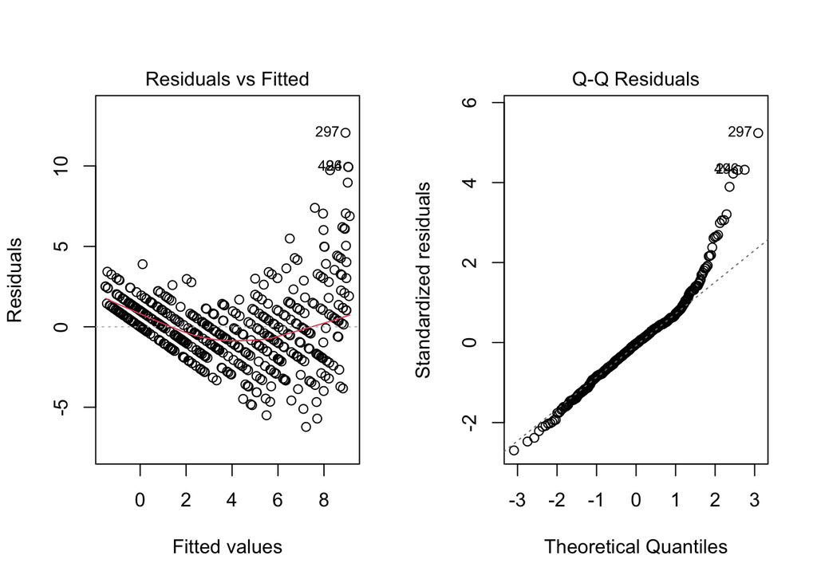

## The Poisson distribution

A probability distribution that is much better equipped for this special case of discrete, yet numeric data is the **Poisson distribution**. It describes counts of events that occur independently of each other and at a constant rate, e.g., within a given period of time or stretch of text (Agresti and Kateri 2022: 50). Assuming a Poisson-distributed variable $X$, its exact shape is determined by a single parameter, $\lambda$ (‘lambda’), which is both its expected value (i.e., the mean) and its variance. In shorthand notation,

$$X \sim Pois(\lambda), \qquad E(X) = Var(X) = \lambda.
\tag{1}$$

Its probability mass function has a notable **positive** (right) skew: Most of the probability mass lies on small counts, with a long tail stretching towards larger counts. Since its skewness coefficient equals $1/\sqrt{\lambda}$, the skew becomes less conspicuous for increasingly higher parameter values (Agresti and Kateri 2022: 51).

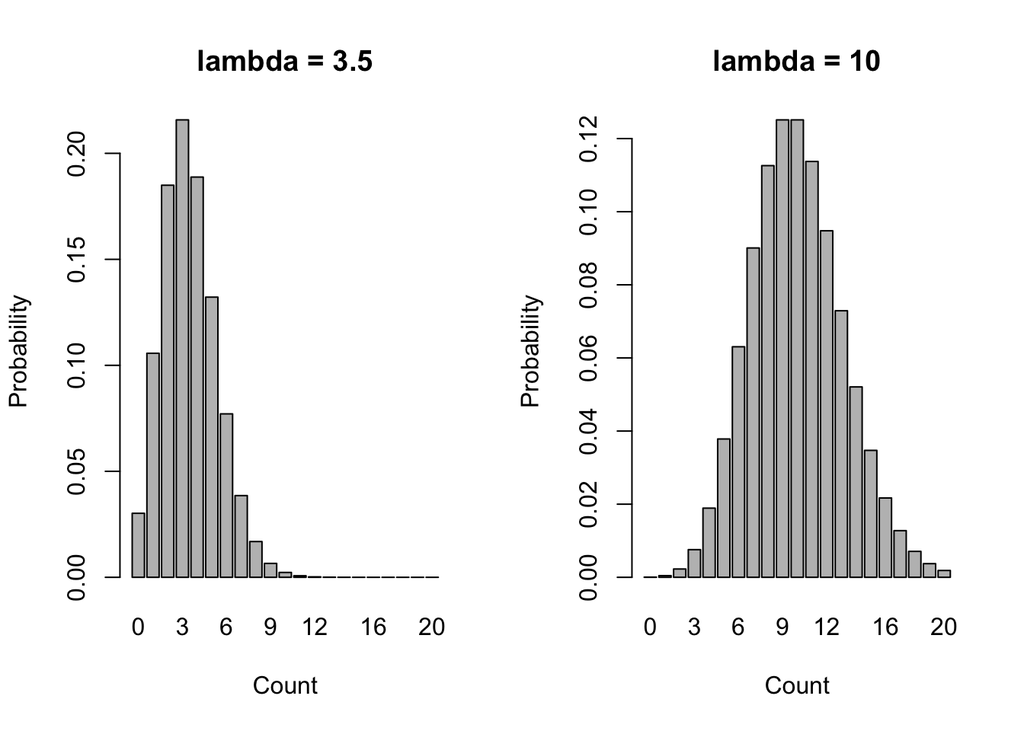

**The Poisson probability mass function**

The probability of observing exactly $k$ events (e.g., $k$ occurrences of a word) is

$$P(X = k) = \frac{\lambda^k e^{-\lambda}}{k!}, \qquad k = 0, 1, 2, \dots
\tag{2}$$

where $k! = k \cdot (k-1) \cdot \ldots \cdot 1$ (and $0! = 1$). For instance, if a word occurs on average $\lambda = 3.5$ times per text, the probability that it does not occur at all in a given text is $P(X = 0) = e^{-3.5} \approx 0.03$. In R, these probabilities are computed by `dpois()`, e.g., `dpois(0, lambda = 3.5)`. For a derivation of the mean and variance, see Agresti and Kateri (2022: 51).

## Poisson regression

Recall how in linear regression, the dependent variable $Y$ was modelled as a function of the linear sum of predictor terms $\beta_pX_p$ for $1, \dots, p$ independent variables.

The **Poisson model** keeps this linear predictor but links it to the response in a different way. Like logistic regression, it is a **generalised linear model** (GLM), which consists of three components: a probability distribution for the response, a linear predictor and a link function connecting the two (Agresti and Kateri 2022: 263–264). It assumes that each observed count $Y$ comes from a Poisson distribution whose expected value $\lambda$ depends on the predictors, and it models the **logarithm** of $\lambda$:

$$Y \sim Pois(\lambda), \qquad \ln(\lambda) = \beta_0 + \beta_1X_1 + \beta_2X_2 + ... + \beta_pX_p.
\tag{3}$$

Two aspects of this model are worth noting:

- It is the expected count $\lambda$ that is log-transformed, not the observed counts $Y$ themselves. This is fortunate, since $\ln(0)$ is undefined, but zero counts are perfectly common. The logarithm is the **link function** of the model, much like the logit in logistic regression. While the expected count cannot be negative, its logarithm can take any real value, just like the linear predictor (Agresti and Kateri 2022: 264). This also ensures that the predicted counts are always positive.
- There is no separate error term. The random variation of the counts around $\lambda$ is described by the Poisson distribution itself.

To remove the logarithm and obtain the model output on a more intuitive scale, we simply exponentiate both sides:

$$\lambda = e^{\beta_0 + \beta_1X_1 + \beta_2X_2 + ... + \beta_pX_p} = e^{\beta_0} \cdot e^{\beta_1X_1} \cdot e^{\beta_2X_2} \cdot \ldots \cdot e^{\beta_pX_p}.
\tag{4}$$

The right-hand side shows that the predictors do not add to the expected count, but **multiply** it (Baguley 2012: 697; Agresti and Kateri 2022: 285). This is key to interpreting the model output.

### Application in R

The data provided by Winter (2020) contains frequency data for several hundred English adjectives (`Freq` column) as well as ratings of how strongly they are experienced through each of the five senses (`Sight`, `Touch`, `Sound`, `Taste` and `Smell`). The ratings range from 0 to 5 and were originally compiled by Lynott and Connell (2009).

```r
head(adjectives)
```

```
# A tibble: 6 × 9
  Word      DominantModality Sight Touch Sound  Taste  Smell Log10Freq  Freq
  <chr>     <chr>            <dbl> <dbl> <dbl>  <dbl>  <dbl>     <dbl> <dbl>
1 abrasive  Haptic            2.89 3.68  1.68  0.579  0.579      1.36     23
2 absorbent Visual            4.14 3.14  0.714 0.476  0.476      0.903     8
3 aching    Haptic            2.05 3.67  0.667 0.0476 0.0952     2.02    105
4 acidic    Gustatory         2.19 1.14  0.476 4.19   2.90       1.04     11
5 acrid     Olfactory         1.12 0.625 0.375 3      3.5        0.301     2
6 adhesive  Haptic            3.67 4.33  1.19  0.905  1.76       1.67     47
```

We will examine the effects of the different sensory ratings on the frequency of an adjective. When fitting the generalised linear model with `glm()`, it is important to specify the argument `family = "poisson"`, which applies the logarithmic link function.

```r
# Fit Poisson regression model
freq.m1 <- glm(Freq ~ Sight + Touch + Sound + Taste + Smell, data = adjectives, family = "poisson")

# Summarise model statistics
summary(freq.m1)
```

```
Call:
glm(formula = Freq ~ Sight + Touch + Sound + Taste + Smell, family = "poisson",
    data = adjectives)

Coefficients:
              Estimate Std. Error z value Pr(>|z|)
(Intercept)  3.1201624  0.0118785  262.67   <2e-16 ***
Sight        0.8726608  0.0024550  355.46   <2e-16 ***
Touch        0.1490792  0.0009801  152.10   <2e-16 ***
Sound        0.1692741  0.0011662  145.15   <2e-16 ***
Taste        0.0790246  0.0019106   41.36   <2e-16 ***
Smell       -0.0963918  0.0019746  -48.82   <2e-16 ***
---
Signif. codes:  0 '***' 0.001 '**' 0.01 '*' 0.05 '.' 0.1 ' ' 1

(Dispersion parameter for poisson family taken to be 1)

    Null deviance: 1890910  on 361  degrees of freedom
Residual deviance: 1633858  on 356  degrees of freedom
  (61 observations deleted due to missingness)
AIC: 1636345

Number of Fisher Scoring iterations: 7
```

As in logistic regression, the estimates are on the scale of the link function, i.e., they indicate changes in the **log** of the expected frequency. Note also that `glm()` silently removes all rows with missing values (see the line `observations deleted due to missingness`).

The model has identified numerous significant effects, i.e., $\beta$-values that are significantly different from 0. The standard errors are tiny, resulting in 95% confidence intervals that are barely visible in the effect plots below. The plots show the predicted frequencies for each rating, with all other predictors held constant at their mean values.

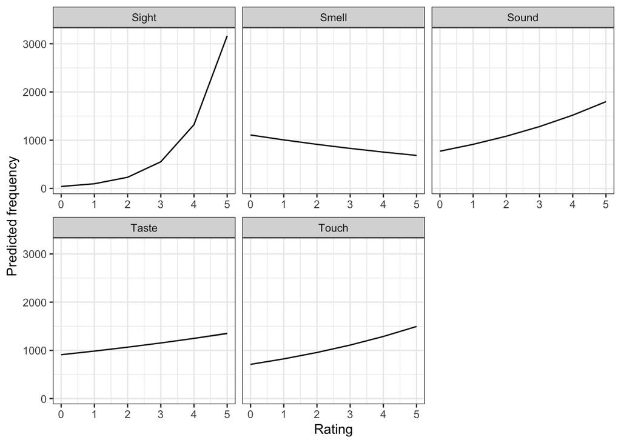

```r
# Get predicted values for each predictor
pred_sight <- ggpredict(freq.m1, terms = "Sight")
pred_touch <- ggpredict(freq.m1, terms = "Touch")
pred_sound <- ggpredict(freq.m1, terms = "Sound")
pred_taste <- ggpredict(freq.m1, terms = "Taste")
pred_smell <- ggpredict(freq.m1, terms = "Smell")

# For plotting individual predictions, simply use:
# plot(pred_sight)

# Combine all predictions into one data frame
pred_all <- rbind(
  data.frame(pred_sight, predictor = "Sight"),
  data.frame(pred_touch, predictor = "Touch"),
  data.frame(pred_sound, predictor = "Sound"),
  data.frame(pred_taste, predictor = "Taste"),
  data.frame(pred_smell, predictor = "Smell")
)

# Create faceted plot
ggplot(pred_all, aes(x = x, y = predicted)) +
  geom_line() +
  geom_ribbon(aes(ymin = conf.low, ymax = conf.high), alpha = 0.5) +
  facet_wrap(~predictor, scales = "free_x") +
  labs(x = "Rating", y = "Predicted frequency") +
  theme_bw()
```

### Interpretation

Since the predictors multiply the expected count (Equation 4), a one-unit increase in $X$ changes the expected count by the factor $e^\beta$. Equivalently, the percentage increase (or decrease, respectively) is given by $100(e^\beta - 1)$ (Baguley 2012: 697). For coefficients close to zero, $\beta$ itself approximates the proportional change, e.g., $\beta = 0.08$ corresponds to an increase of roughly 8%. This shortcut becomes increasingly inaccurate as $\beta$ moves away from zero, e.g., beyond $\pm 0.2$ (Baguley 2012: 697).

As we can see, adjectives with higher `Sight` ratings (i.e., highly visual adjectives) are associated with the greatest increase in frequency of occurrence. The predictor `Sight` has an estimate of approximately $0.87$ ($p < 0.001$, 95% CI [0.87, 0.88]), so each one-unit increase in the sight rating multiplies the expected frequency by $e^{0.87} \approx 2.39$. This corresponds to an increase of $100(e^{0.87} - 1) \approx 138.69\%$.

By contrast, `Smell` is associated with a lower frequency: Its estimate of $-0.1$ translates into a change of $100(e^{-0.1} - 1) \approx -9.52\%$ for each one-unit increase in smell ratings. In essence: Smelly adjectives are unpopular!

Or are they? Before we draw any conclusions, we need to check a crucial assumption of the model.

## Overdispersion

According to Equation 1, the variance of a Poisson-distributed variable equals its mean. In practice, however, counts often vary much more than the Poisson model allows, which is called **overdispersion** (Agresti and Kateri 2022: 51–52). A common cause is heterogeneity: If the rate at which an event occurs varies between observations because of factors that are not part of the model, the counts effectively stem from a mixture of Poisson distributions with different means. Such a mixture has a larger variance than a single Poisson distribution (Agresti and Kateri 2022: 52, 288–289). Linguistic frequency data is a prime example: Words are not spread evenly across texts, but tend to cluster in texts on particular topics, so that their rate of occurrence varies considerably.

If the model is otherwise correctly specified, i.e., it has the right link function and predictors, overdispersion does not invalidate the estimates themselves, but it causes the model to **underestimate the standard errors** (Agresti and Kateri 2022: 289; Baguley 2012: 696). As a result, the $p$-values are too small and the confidence intervals too narrow. The tiny standard errors we observed above are therefore not a sign of robust estimates, but a warning sign.

A simple diagnostic is the **dispersion ratio** $\hat{\varphi}$ (‘phi hat’), i.e., the sum of the squared Pearson residuals (the Pearson $\chi^2$ statistic) divided by the residual degrees of freedom (Baguley 2012: 695–696). If the Poisson assumption holds, it should be close to 1.

```r
# Dispersion ratio
dispersion <- sum(residuals(freq.m1, type = "pearson")^2) / df.residual(freq.m1)

dispersion
```

```
[1] 13380.68
```

Owing to sampling error, $\hat{\varphi}$ will hardly ever be exactly 1. There is no universally agreed threshold, but even small deviations matter: With $\hat{\varphi} = 1.2$, the standard errors are almost 10% too small, and values of 2 or more are considered a serious problem (Baguley 2012: 695–696). A ratio of about 13381 means that the residual variance is roughly 13381 times larger than what the Poisson model assumes, so it is clearly inappropriate for these data.

Note, however, that apparent overdispersion can also result from a poorly specified model, e.g., when important predictors are missing. Similarly, if the data contain several counts from the same speakers or texts, a mixed-effects model should be considered (Baguley 2012: 698).

### Negative binomial regression

Instead of merely correcting the standard errors, the preferred approach is to fit a model that allows the variance to differ from the mean (Baguley 2012: 699). A popular option is **negative binomial regression**. It has the same log link and the same interpretation as the Poisson model, but it adds a dispersion parameter $\theta$ (‘theta’) that allows the variance to exceed the mean (Agresti and Kateri 2022: 290; Baguley 2012: 702–703):

$$Var(Y) = \lambda + \frac{\lambda^2}{\theta}.
\tag{5}$$

The smaller $\theta$, the stronger the overdispersion; as $\theta$ grows very large, the model approaches the Poisson model. The negative binomial distribution can be derived as a mixture of Poisson distributions whose means vary according to a gamma distribution, which corresponds directly to the heterogeneity described above (Agresti and Kateri 2022: 289–290). Negative binomial models can be fitted with `glm.nb()` from the `MASS` package, which comes pre-installed with R.

```r
# Fit negative binomial regression model
# MASS:: accesses the function without loading the package,
# which would otherwise mask dplyr's select() function
freq.nb <- MASS::glm.nb(Freq ~ Sight + Touch + Sound + Taste + Smell, data = adjectives)

summary(freq.nb)
```

```
Call:
MASS::glm.nb(formula = Freq ~ Sight + Touch + Sound + Taste +
    Smell, data = adjectives, init.theta = 0.3420955584, link = log)

Coefficients:
            Estimate Std. Error z value Pr(>|z|)
(Intercept)  3.44597    0.47589   7.241 4.45e-13 ***
Sight        0.79536    0.09727   8.177 2.92e-16 ***
Touch        0.11745    0.06249   1.880  0.06017 .
Sound        0.16258    0.07022   2.315  0.02060 *
Taste        0.27700    0.09885   2.802  0.00507 **
Smell       -0.21349    0.10452  -2.043  0.04109 *
---
Signif. codes:  0 '***' 0.001 '**' 0.01 '*' 0.05 '.' 0.1 ' ' 1

(Dispersion parameter for Negative Binomial(0.3421) family taken to be 1)

    Null deviance: 563.53  on 361  degrees of freedom
Residual deviance: 485.45  on 356  degrees of freedom
  (61 observations deleted due to missingness)
AIC: 5325.6

Number of Fisher Scoring iterations: 1

              Theta:  0.3421
          Std. Err.:  0.0204

 2 x log-likelihood:  -5311.6140
```

The output resembles that of the Poisson model, with the estimated $\theta$ reported at the bottom. Crucially, the standard errors are now considerably larger. Both models can be compared using the AIC (lower values indicate a better fit; see 4.2 Logistic regression and Agresti and Kateri (2022: 291) for an example):

```r
AIC(freq.m1, freq.nb)
```

```
        df         AIC
freq.m1  6 1636344.798
freq.nb  7    5325.614
```

The difference in the confidence intervals becomes evident when we plot the predictions of both models for `Sight`:

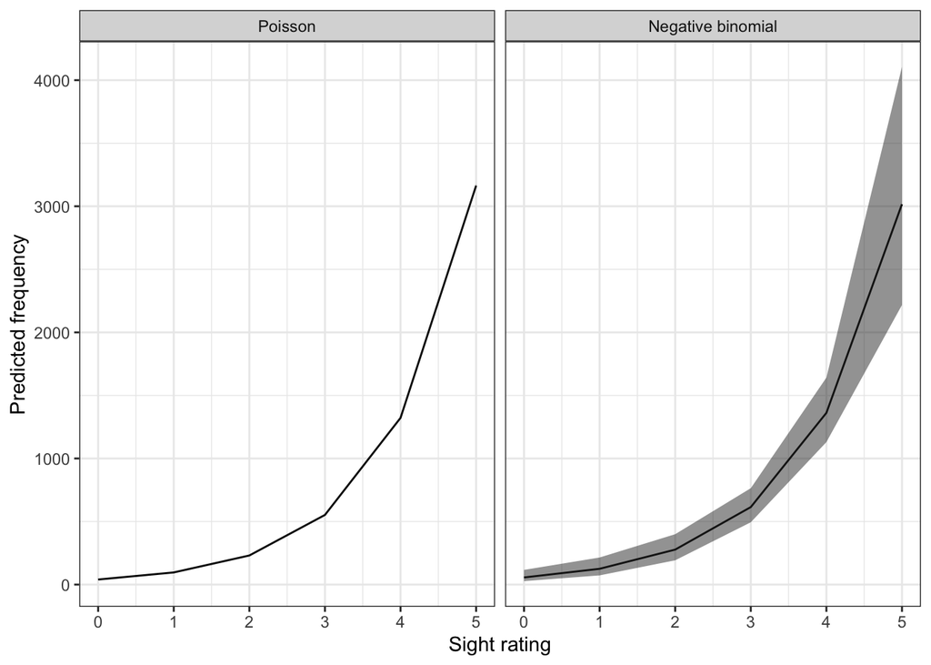

```r
pred_sight_nb <- ggpredict(freq.nb, terms = "Sight")

pred_comp <- rbind(
  data.frame(pred_sight, model = "Poisson"),
  data.frame(pred_sight_nb, model = "Negative binomial")
)

# Show the Poisson model first
pred_comp$model <- factor(pred_comp$model, levels = c("Poisson", "Negative binomial"))

ggplot(pred_comp, aes(x = x, y = predicted)) +
  geom_line() +
  geom_ribbon(aes(ymin = conf.low, ymax = conf.high), alpha = 0.5) +
  facet_wrap(~model) +
  labs(x = "Sight rating", y = "Predicted frequency") +
  theme_bw()
```

The coefficients are interpreted exactly as before, using $100(e^\beta - 1)$.

Count data with many more zeros than expected under either distribution, e.g., because some texts simply never contain the phenomenon in question, may call for zero-inflated or hurdle models, which are beyond the scope of this handout (Baguley 2012: 695, 704–705).

**Quasi-Poisson models**

An alternative to the negative binomial model is the **quasi-Poisson** model, which can be fitted with `glm(..., family = "quasipoisson")`. It assumes that the variance is proportional to the mean, i.e., $Var(Y) = \varphi\lambda$, and produces the same estimates as the Poisson model, but multiplies the standard errors by $\sqrt{\hat{\varphi}}$ (Baguley 2012: 696, 702). Since it does not rely on a full probability distribution, it does not provide an AIC. Note the difference to the negative binomial model, whose variance increases quadratically with the mean (Equation 5). The choice between the two is not always easy, but since the negative binomial model is arguably the more principled approach, Baguley (2012: 703–704) recommends it as the default.

## Counts from texts of different sizes: Offsets

In corpus linguistics, counts are often obtained from texts or subcorpora of different sizes. A text with 10,000 words naturally contains more passives than one with 1,000 words, regardless of its register. Here, we are interested in **rates** (e.g., passives per word) rather than raw counts. Whenever the opportunity to observe the event differs between observations, the model needs to take this **exposure** into account (Baguley 2012: 700).

Poisson and negative binomial models handle this by means of an **offset**, i.e., the logarithm of the text size, which is added to the model as a predictor whose coefficient is fixed at 1 rather than estimated (Agresti and Kateri 2022: 286; Baguley 2012: 700–701):

$$\ln(\lambda) = \ln(\text{text size}) + \beta_0 + \beta_1X_1 + ... + \beta_pX_p \quad \Leftrightarrow \quad \ln\left(\frac{\lambda}{\text{text size}}\right) = \beta_0 + \beta_1X_1 + ... + \beta_pX_p
\tag{6}$$

The model on the right is a model of the rate $\lambda / \text{text size}$. In R, we wrap the offset in `offset()`. For a hypothetical data frame `passive_data` with one row per text, the passive counts `n_passives`, the text sizes `n_words` and the `register` of each text, the model would look as follows:

```r
passive.m <- MASS::glm.nb(n_passives ~ register + offset(log(n_words)), data = passive_data)
```

The exponentiated coefficients now indicate by which factor the **rate** of passives changes, e.g., from one register to another. This is preferable to modelling relative frequencies (e.g., passives per 1,000 words) with a linear model, since the counts retain the information about how much text each rate is based on.

## Exercises

**Exercise 1** Compute the percentage changes in the expected frequency for `Touch`, `Sound` and `Taste` in the Poisson model `freq.m1` and interpret them.

**Exercise 2** Compare the output of the negative binomial model `freq.nb` with that of the Poisson model `freq.m1`. Which predictors still have a significant effect on frequency? How do the estimates and their standard errors differ? Does the conclusion that smelly adjectives are unpopular still hold?

**Exercise 3** Fit a quasi-Poisson model to the adjective data and verify that its standard errors equal those of the Poisson model multiplied by $\sqrt{\hat{\varphi}}$ (up to rounding).

**Exercise 4** All frequencies in the adjective data were taken from the same corpus. Would it make sense to include an offset in the model? Why or why not?

## References

Agresti, Alan, and Maria Kateri. 2022. *Foundations of Statistics for Data Scientists: With r and Python*. Boca Raton: CRC Press.

Baguley, Thomas. 2012. *Serious Stats: A Guide to Advanced Statistics for the Behavioral Sciences*. Houndmills, Basingstoke: Palgrave Macmillan.

Gelman, Andrew, and Jennifer Hill. 2007. *Data Analysis Using Regression and Multilevel/Hierarchical Models*. Analytical Methods for Social Research. Cambridge: Cambridge University Press.

Lynott, Dermot, and Louise Connell. 2009. “Modality Exclusivity Norms for 423 Object Properties.” *Behavior Research Methods* 41: 558–64. https://doi.org/10.3758/BRM.41.2.558.

Winter, Bodo. 2020. *Statistics for Linguists: An Introduction Using r*. New York; London: Routledge.